# Elsevier 2022 SDG mapping

(

(

TITLE-ABS

(

"inclusive curriculum"

)

OR AUTHKEY

(

"inclusive curriculum"

)

OR TITLE-ABS

(

"Education* needs*"

)

OR AUTHKEY

(

"Education* needs*"

)

)

)

## Subfields of science

In this section, we show how the publication set, captured by the query above, relates to the [Science-Metrix classification system](https://science-metrix.com/?q=en/classification)

As shown in figure 1, the publications related to this publication set fall mainly under the subfields of Education (186,110 publications), Nursing (14,405), and Business & Management (12,206). Percentages alongside each subfield indicate the total share of each subfield included under the publication set.

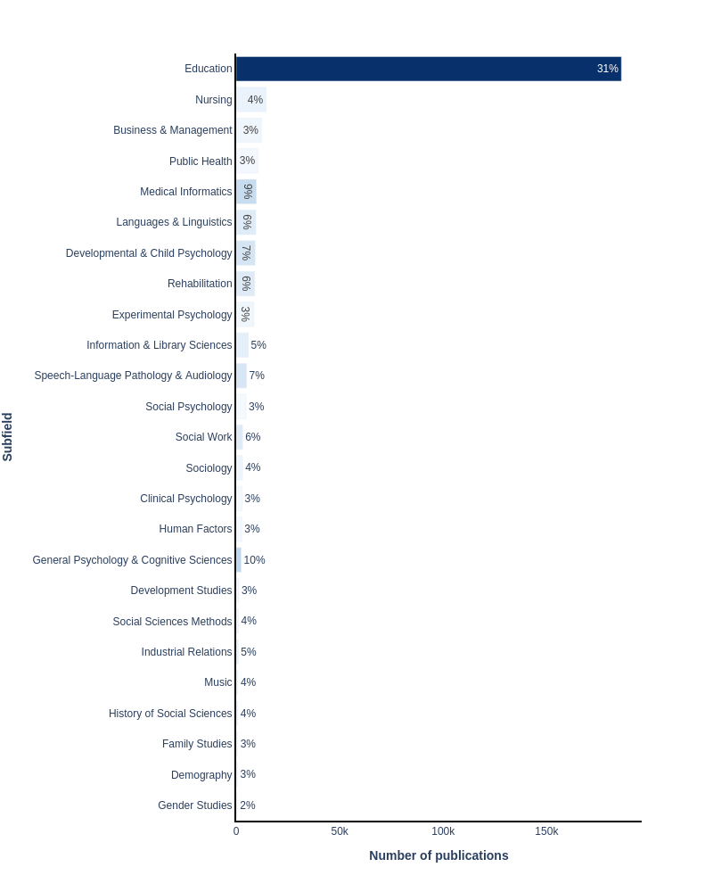

## Journals

In this section, we show how the publication set, captured by the query above, relates to scholarly journals. Journals are sorted in terms of their relevance using term frequency-inverse document frequency (TF-IDF). The horizontal bars are proportional to the number of publications contributed by the journal to the current publication set. The number alongside the horizontal bar is the proportion of the journal contributing to this publication set.

The articles on this topic are published most frequently in the following journals: *ASEE Annual Conference and Exposition, Conference Proceedings* (6,717 publications), *Journal of Physics: Conference Series* (5,288), and *Lecture Notes in Computer Science (including subseries Lecture Notes in Artificial Intelligence and Lecture Notes in Bioinformatics)* (5,142).

Note, larger journals may not appear in the table below, as their SDG contribution may be relatively small compared to the size of the journal.

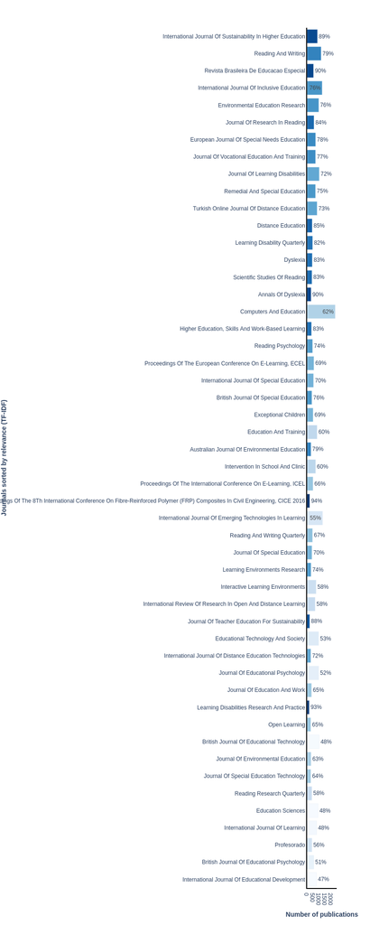

Figure 2. Top 50 journals, in terms of relevance (TF-IDF), for this publication set.

## Keywords

Elsevier’s [Scopus](https://www.scopus.com/search/form.uri?display=basic#basic) database of scientific literature, was used for the table below. The document types included in the data sets are journal articles, reviews, short surveys and conference papers, covering the period 1996–2022. We refer to these documents collectively as “publications” or “papers”.

In order to help better illustrate the content of this set of publications, indicators associated with the keywords most specific to this set (according to a TF-IDF score) are presented below.

|  | Term | # of papers with this term in the publication set | # of papers with this term in all of Scopus | Relevance (TF-IDF) | Percentage of Scopus |
| --- | --- | --- | --- | --- | --- |
| 1 | interactive learning environments | 1466 | 1601 | 18.7211 | 92 |
| 2 | reading fluency | 1901 | 2111 | 18.7143 | 90 |
| 3 | active learning environments | 1563 | 1752 | 18.6819 | 89 |
| 4 | reading intervention | 1143 | 1253 | 18.6673 | 91 |
| 5 | interactive learning environment | 2090 | 2387 | 18.6638 | 88 |
| 6 | phonological awareness | 3672 | 4079 | 18.6589 | 90 |
| 7 | reading development | 1483 | 1761 | 18.571 | 84 |
| 8 | active learning environment | 2500 | 2991 | 18.569 | 84 |
| 9 | emergent literacy | 1035 | 1189 | 18.5604 | 87 |
| 10 | reading difficulties | 1776 | 2160 | 18.5427 | 82 |

[output cut: 990 more lines]